# Statistical Learning HW7 实战

Ding Zepeng,18307110088

2020/12/13

# 1 读入数据：

```r
rm(list=ls())
data1 <- read.csv("simudata.csv", header = T)
head(data1)
```

|  | creded | debitF | meanpay | billnum | debitM | zhongxingM | sidaM | xindaiR | cardnum | xindaiF | maxpay | zhuanzhangF | gongjiaoF | zhuanzhangR | age | gongjiaoR | sidaF | sidaR | zhongxingF | zhongxingR | xiaofeiF | jinkaF | zhuanzhangM | gongjiaoM | youxiM | xindaiS | black |
| --- | --- | --- | --- | --- | --- | --- | --- | --- | --- | --- | --- | --- | --- | --- | --- | --- | --- | --- | --- | --- | --- | --- | --- | --- | --- | --- | --- |
| 1 | 0.02 | 28 | 474795 | 4 | 784137.54 | 56826 | 307042 | 365.00 | 2 | 6 | 1665922.93 | 69 | 0 | 359.61 | 26 | 349.43 | 7 | 7.83 | 4 | 334.38 | 6 | 9 | 508646.0 | 297.83 | 66.02 | 5760.22 | 1 |
| 2 | 0.16 | 2 | 346573 | 32 | 1217.43 | 43644 | 15096 | 311.73 | 9 | 0 | 9781.23 | 2 | 2 | 95.68 | 29 | 365.00 | 4 | 91.77 | 14 | 365.00 | 1 | 11 | 425876.2 | 3521.03 | 22.75 | 83872.62 | 1 |
| 3 | 0.32 | 56 | 168844 | 191 | 95001.76 | 279217 | 69815 | 42.32 | 8 | 0 | 4448852.49 | 33 | 1 | 230.09 | 30 | 365.00 | 64 | 36.05 | 10 | 27.08 | 1 | 2 | 492287.8 | 467.64 | 6.66 | 31110.55 | 1 |
| 4 | 0.01 | 28 | 69002 | 89 | 487782.48 | 273731 | 329437 | 81.60 | 15 | 1 | 8876.84 | 7 | 0 | 267.48 | 30 | 330.19 | 2 | 10.08 | 8 | 191.04 | 1 | 8 | 240067.3 | 288.67 | 119.98 | 7876.13 | 1 |
| 5 | 0.19 | 6 | 408647 | 104 | 22039.56 | 13529 | 24725 | 254.60 | 17 | 9 | 1975116.83 | 1 | 2 | 156.96 | 29 | 324.66 | 11 | 324.21 | 23 | 248.39 | 7 | 0 | 455464.5 | 11834.25 | 28.97 | 13765.38 | 0 |
| 6 | 0.20 | 65 | 285313 | 3 | 194798.70 | 11285 | 17961 | 50.31 | 5 | 0 | 2278266.73 | 17 | 1 | 144.48 | 24 | 365.00 | 6 | 237.08 | 0 | 361.47 | 4 | 0 | 192392.7 | 527.81 | 27.45 | 161711.43 | 0 |

# 2 按要求划分训练集、测试集并用多种模型建模(ROC见下一小节)：

```r
set.seed(1234)
# 7:3划分训练集和测试集
sub <- sample(1:nrow(data1),round(nrow(data1)*0.7))
traindata <- data1[sub,]   #取0.7的数据做训练集
testdata <- data1[-sub,]   #取0.3的数据做测试集
```

## 2.1 逻辑回归

```r
# 用glm构建逻辑回归模型
logist <- glm(black ~ ., data = traindata, family = binomial(link = "logit"))
summary(logist)
```

```
##
## Call:
## glm(formula = black ~ ., family = binomial(link = "logit"), data = traindata)
##
## Deviance Residuals:
##     Min       1Q   Median       3Q      Max
## -2.4889  -0.7528  -0.3981   0.7835   3.2265
##
## Coefficients:
##               Estimate Std. Error z value Pr(>|z|)
## (Intercept) -7.029e+00  5.972e-01 -11.769  < 2e-16 ***
## creded      -4.043e+00  2.674e-01 -15.117  < 2e-16 ***
## debitF      -1.213e-02  1.044e-03 -11.626  < 2e-16 ***
## meanpay     -2.411e-06  1.625e-07 -14.841  < 2e-16 ***
## billnum     -4.111e-03  5.055e-04  -8.132 4.21e-16 ***
## debitM      -4.773e-07  1.305e-07  -3.656 0.000256 ***
## zhongxingM  -5.020e-07  1.992e-07  -2.520 0.011736 *
## sidaM       -1.006e-06  1.439e-07  -6.992 2.72e-12 ***
## xindaiR      5.152e-03  3.327e-04  15.485  < 2e-16 ***
## cardnum      1.124e-01  7.841e-03  14.337  < 2e-16 ***
## xindaiF      1.133e-01  9.376e-03  12.085  < 2e-16 ***
## maxpay       3.337e-07  2.936e-08  11.366  < 2e-16 ***
## zhuanzhangF  1.791e-02  1.475e-03  12.143  < 2e-16 ***
## gongjiaoF    2.159e-01  2.526e-02   8.550  < 2e-16 ***
## zhuanzhangR  2.599e-03  2.696e-04   9.637  < 2e-16 ***
## age          6.547e-02  7.789e-03   8.406  < 2e-16 ***
## gongjiaoR    5.464e-03  1.409e-03   3.877 0.000106 ***
## sidaF        4.329e-03  1.333e-03   3.248 0.001162 **
## sidaR        9.554e-04  3.425e-04   2.789 0.005286 **
## zhongxingF   1.506e-02  3.994e-03   3.772 0.000162 ***
## zhongxingR   9.495e-04  3.177e-04   2.988 0.002805 **
## xiaofeiF     3.720e-02  1.088e-02   3.418 0.000630 ***
## jinkaF       1.448e-02  4.798e-03   3.017 0.002551 **
## zhuanzhangM -2.570e-07  1.158e-07  -2.219 0.026499 *
## gongjiaoM    1.554e-05  4.458e-06   3.486 0.000490 ***
## youxiM       3.171e-04  1.280e-04   2.478 0.013228 *
## xindaiS      9.840e-07  3.551e-07   2.771 0.005589 **
## ---
## Signif. codes:  0 '***' 0.001 '**' 0.01 '*' 0.05 '.' 0.1 ' ' 1
##
## (Dispersion parameter for binomial family taken to be 1)
##
##     Null deviance: 7145.8  on 5621  degrees of freedom
## Residual deviance: 5336.1  on 5595  degrees of freedom
## AIC: 5390.1
##
## Number of Fisher Scoring iterations: 5
```

```r
# 在测试集上测试
predval.logist <- as.numeric(predict(logist, type = "response", newdata = testdata))
mean(predval.logist)
```

```
## [1] 0.3345069
```

## 2.2 kNN

```r
# 用class包的knn函数构建K近邻模型
library(class)
knnmodel <- knn(traindata[,-1], testdata[-1], traindata$black, k = 7)

# 保存预测值
predval.knn <- as.numeric(knnmodel) - 1
mean(predval.knn)
```

```
## [1] 0.2323651
```

## 2.3 决策树

```r
# 用rpart包的rpart函数构建决策树模型，用默认参数
library(rpart)
dtree <- rpart(black ~ ., data = traindata)
printcp(dtree)
```

```
##
## Regression tree:
## rpart(formula = black ~ ., data = traindata)
##
## Variables actually used in tree construction:
## [1] creded      meanpay     xindaiR     zhuanzhangF
##
## Root node error: 1246.7/5622 = 0.22175
##
## n= 5622
##
##         CP nsplit rel error  xerror     xstd
## 1 0.033162      0   1.00000 1.00043 0.009526
## 2 0.026577      1   0.96684 0.97830 0.010081
## 3 0.016145      2   0.94026 0.96589 0.010656
## 4 0.010334      3   0.92412 0.94245 0.011033
## 5 0.010081      4   0.91378 0.93952 0.011265
## 6 0.010000      5   0.90370 0.93837 0.011296
```

```r
# 在测试集上测试
predval.dtree <- as.numeric(predict(dtree, newdata = testdata))
mean(predval.dtree)
```

```
## [1] 0.3317272
```

## 2.4 Boosting模型

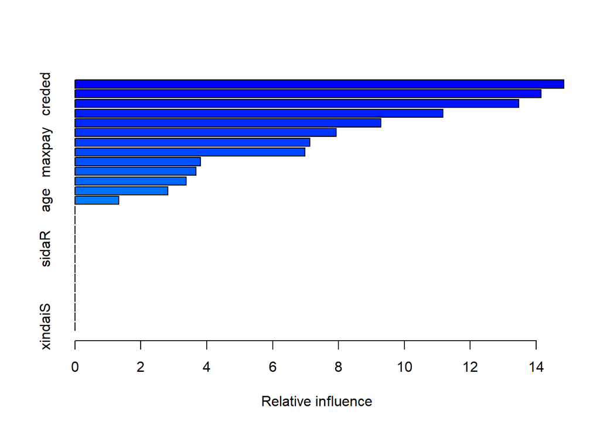

|  | var | rel.inf |
| --- | --- | --- |
| meanpay | meanpay | 14.841928 |
| creded | creded | 14.154735 |
| xindaiR | xindaiR | 13.474763 |
| cardnum | cardnum | 11.170460 |
| zhuanzhangF | zhuanzhangF | 9.290227 |
| xindaiF | xindaiF | 7.929870 |
| debitF | debitF | 7.135043 |
| maxpay | maxpay | 6.981100 |
| sidaM | sidaM | 3.815549 |
| billnum | billnum | 3.671873 |

[output cut: 16 more lines]

```r
# 利用gbm包的gbm函数实现adaboost算法，构建提升树模型
library(gbm)
adbtree <- gbm(black ~ ., data = traindata, distribution = "adaboost")  # 默认参数
summary(adbtree)
```

```r
# 在测试集上测试
predval.adbtree <- as.numeric(predict(adbtree, type = "response", newdata = testdata))
```

```
## Using 100 trees...
```

```r
mean(predval.adbtree)
```

```
## [1] 0.3216844
```

## 2.5 随机森林

```r
# 使用RandomForest包构建随机森林模型
library(randomForest)
```

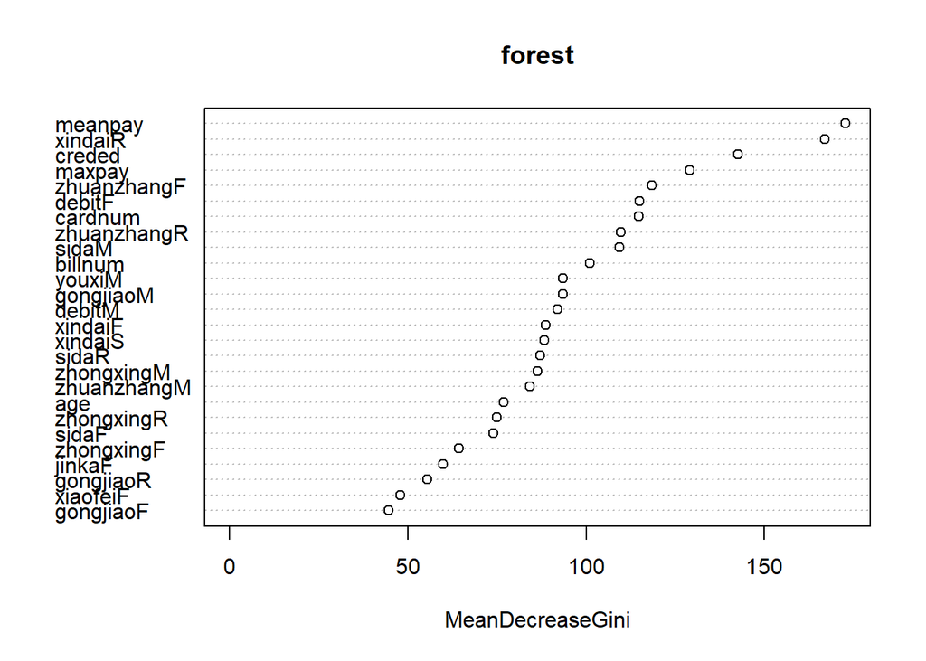

```r
forest <- randomForest(as.factor(black) ~ ., data = traindata)
varImpPlot(forest)
```

```r
# 在测试集上测试
predval.forest <- as.numeric(predict(forest, type = "response", newdata = testdata)) - 1
mean(predval.forest)
```

```
## [1] 0.1751037
```

## 2.6 SVM

```r
# 用e1071包中的svm函数构建支持向量机
library(e1071)
svmmod1 <- svm(black ~ ., data = traindata)   # 默认参数；高斯核
summary(svmmod1)
```

```
##
## Call:
## svm(formula = black ~ ., data = traindata)
##
##
## Parameters:
##    SVM-Type:  eps-regression
##  SVM-Kernel:  radial
##        cost:  1
##       gamma:  0.03846154
##     epsilon:  0.1
##
##
## Number of Support Vectors:  4749
```

```r
svmmod2 <- svm(black ~ ., data = traindata, type = "C-classification")   # SVM分类模型；高斯核
summary(svmmod2)
```

```
##
## Call:
## svm(formula = black ~ ., data = traindata, type = "C-classification")
##
##
## Parameters:
##    SVM-Type:  C-classification
##  SVM-Kernel:  radial
##        cost:  1
##
## Number of Support Vectors:  3397
##
##  ( 1587 1810 )
##
##
## Number of Classes:  2
##
## Levels:
##  0 1
```

```r
# 在测试集上测试
predval.svm1 <- as.numeric(predict(svmmod1, newdata = testdata))
predval.svm2 <- as.numeric(predict(svmmod2, newdata = testdata))
```

# 3 绘制各模型的ROC曲线、计算AUC值并比较：

```r
# ROC曲线与AUC值
library(pROC)
# 构建roc对象
roc.logist <- roc(testdata$black, predval.logist)
roc.knn <- roc(testdata$black, predval.knn)
roc.dtree <- roc(testdata$black, predval.dtree)
roc.adbtree <- roc(testdata$black, predval.adbtree)
roc.forest <- roc(testdata$black, predval.forest)
roc.svm1 <- roc(testdata$black, predval.svm1)
roc.svm2 <- roc(testdata$black, predval.svm2)
```

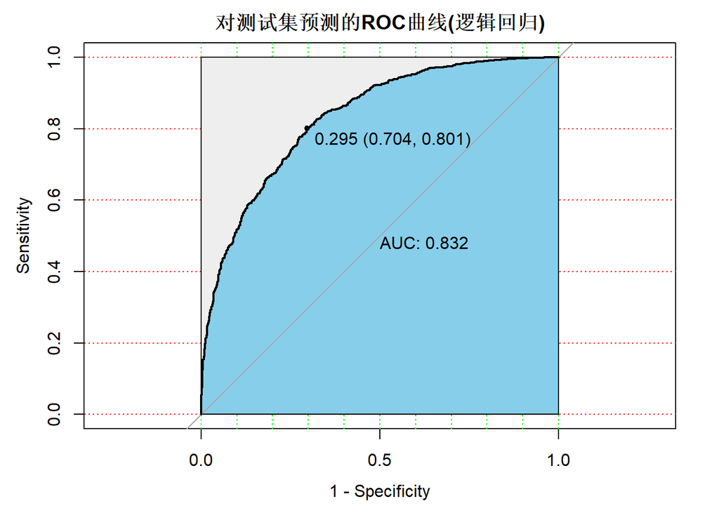

```r
# 画出ROC曲线，标出坐标，并标出AUC的值
plot(roc.logist, print.auc=TRUE, main="对测试集预测的ROC曲线(逻辑回归)", auc.polygon=TRUE, grid=c(0.1, 0.2),
     grid.col=c("green", "red"), max.auc.polygon=TRUE,
     auc.polygon.col="skyblue", print.thres=TRUE, legacy.axes = T)
```

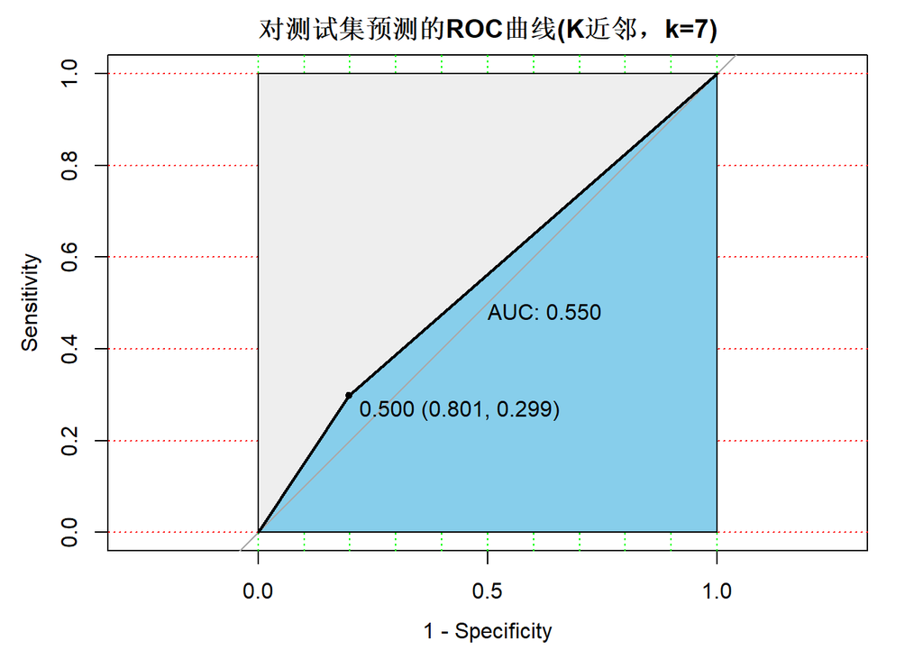

```r
plot(roc.knn, print.auc=TRUE, main="对测试集预测的ROC曲线(K近邻，k=7)", auc.polygon=TRUE, grid=c(0.1, 0.2),
     grid.col=c("green", "red"), max.auc.polygon=TRUE,
     auc.polygon.col="skyblue", print.thres=TRUE, legacy.axes = T)
```

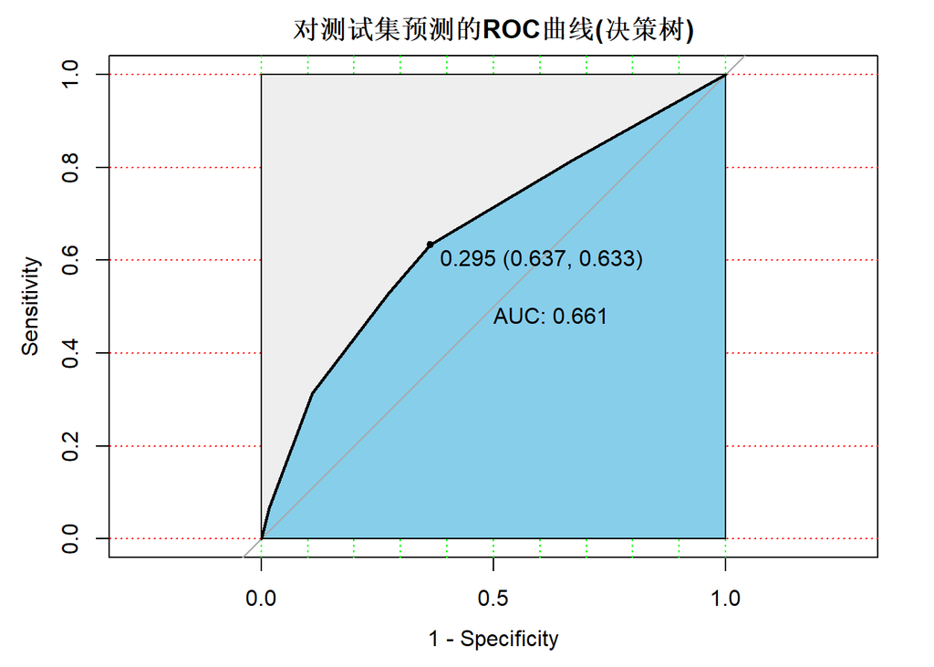

```r
plot(roc.dtree, print.auc=TRUE, main="对测试集预测的ROC曲线(决策树)", auc.polygon=TRUE, grid=c(0.1, 0.2),
     grid.col=c("green", "red"), max.auc.polygon=TRUE,
     auc.polygon.col="skyblue", print.thres=TRUE, legacy.axes = T)
```

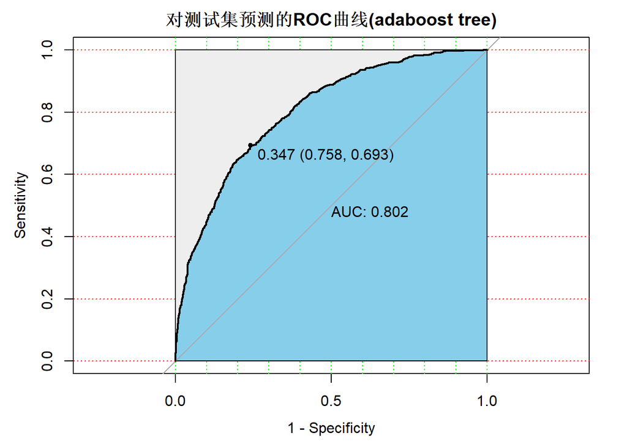

```r
plot(roc.adbtree, print.auc=TRUE, main="对测试集预测的ROC曲线(adaboost tree)", auc.polygon=TRUE, grid=c(0.1, 0.2),
     grid.col=c("green", "red"), max.auc.polygon=TRUE,
     auc.polygon.col="skyblue", print.thres=TRUE, legacy.axes = T)
```

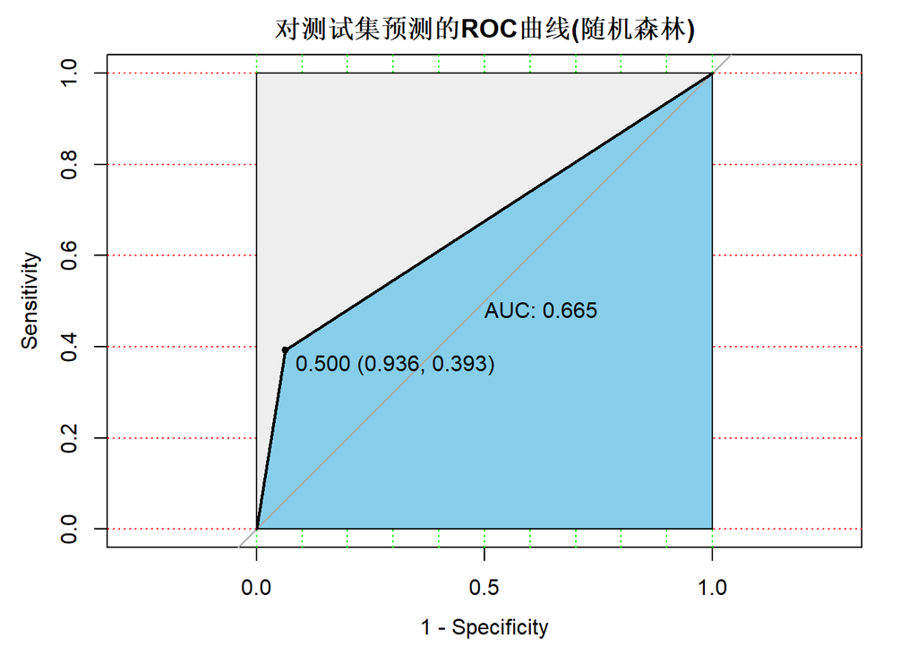

```r
plot(roc.forest, print.auc=TRUE, main="对测试集预测的ROC曲线(随机森林)", auc.polygon=TRUE, grid=c(0.1, 0.2),
     grid.col=c("green", "red"), max.auc.polygon=TRUE,
     auc.polygon.col="skyblue", print.thres=TRUE, legacy.axes = T)
```

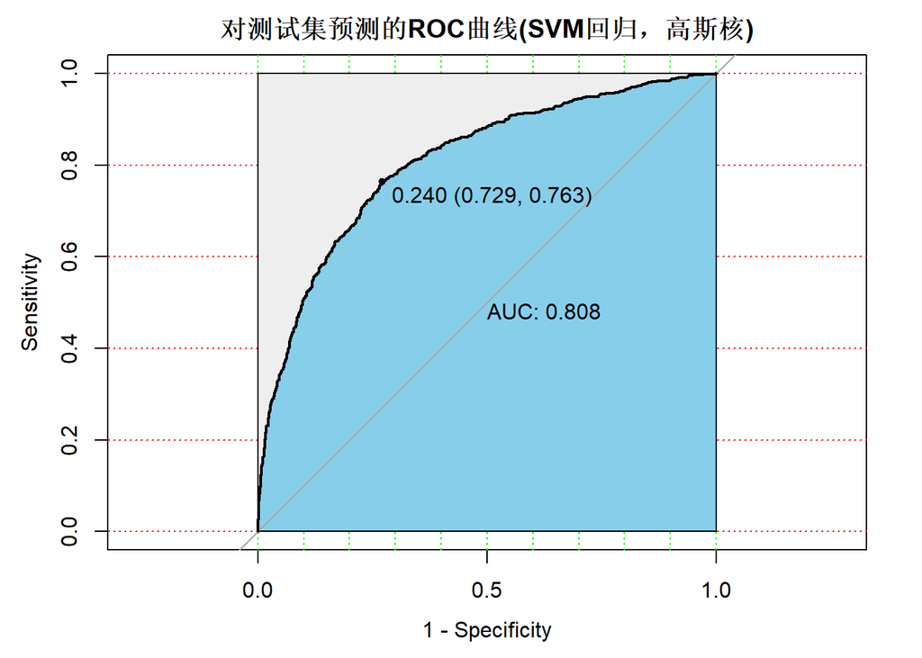

```r
plot(roc.svm1, print.auc=TRUE, main="对测试集预测的ROC曲线(SVM回归，高斯核)", auc.polygon=TRUE, grid=c(0.1, 0.2),
     grid.col=c("green", "red"), max.auc.polygon=TRUE,
     auc.polygon.col="skyblue", print.thres=TRUE, legacy.axes = T)
```

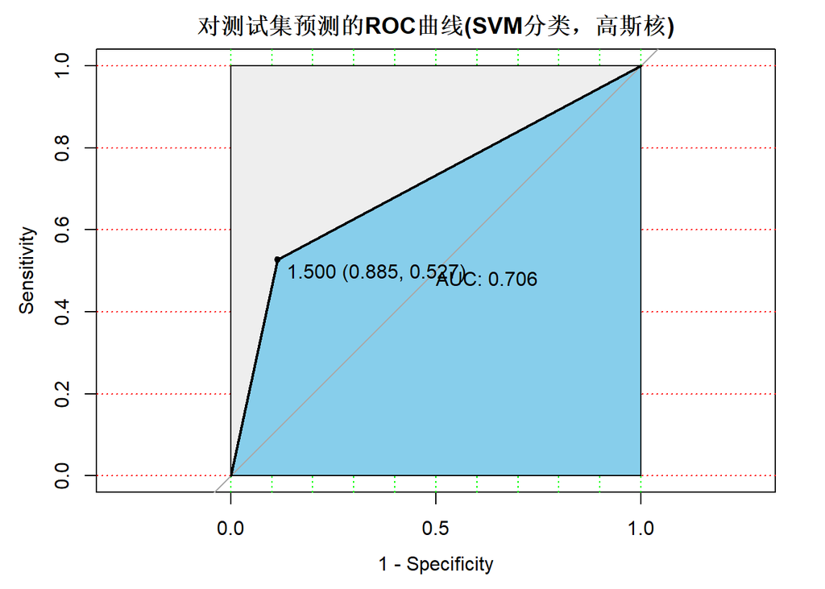

```r
plot(roc.svm2, print.auc=TRUE, main="对测试集预测的ROC曲线(SVM分类，高斯核)", auc.polygon=TRUE, grid=c(0.1, 0.2),
     grid.col=c("green", "red"), max.auc.polygon=TRUE,
     auc.polygon.col="skyblue", print.thres=TRUE, legacy.axes = T)
```

- 解读与选择：首先需要说明的是，因为模型及方法不同，有些预测值是离散的（0或1）而有些是连续的（表征“概率”意义，或者说越接近1说明越可能违约）。因此做出的ROC曲线形状不同，**对于离散预测值其ROC曲线看上去“分段”明显，不连续；而对于连续预测值其ROC曲线看上去比较连续**
- 此外，对同一个模型如SVM，选择其不同方法得到的AUC值也不同（如SVM回归eps-regression和SVM分类C-classification，前者的AUC值高于后者）。但总体而言与其他同类型（即分段型与分段型相比，连续型与连续型相比）ROC曲线相比，不同模型AUC值的**相对**大小是一样的，比如即便是SVM分类模型的AUC值也要高于决策树。
- 因此，从AUC值的意义上，KNN模型效果最差（几乎和随机猜测一样）；随机森林略优于单个决策树；**boosting方法、sVM和逻辑回归的AUC值都很高，这三种模型都不错**。如果非要在AUC意义上选取最优模型的话，**逻辑回归模型**效果最好。